# Annelids only - 133 CS

2023-10-17

## Script to work on analyses for causes paper

## Taxonomic work is needed? # Morpho differentiation types: More CS sl than CS ss overall? # Need to find expectations and test against 50:50 mark

```
##
##  Pearson's Chi-squared test with Yates' continuity correction
##
## data:  cbind(expected, observed)
## X-squared = 4.2034, df = 1, p-value = 0.04034
```

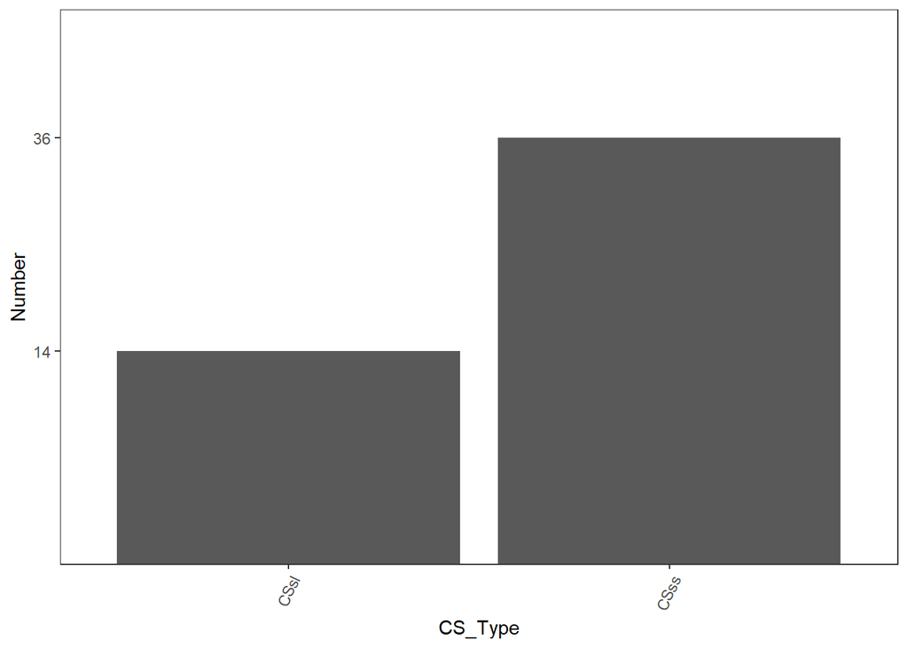

More CSss than the 50% benchmark (significant), so reject the idea that most CS are just due to taxonomic oversight.

## Available technology – More diagnostic differences in species described earlier?

```
##
##        FALSE TRUE
##   1760     0    1
##   1770     0    2
##   1800     0    1
##   1810     0    1
##   1820     0    1
##   1830     3    1
##   1840     0    2
##   1850     0    1
##   1860     3    4
##   1870     0    1
##   1880     0    1
##   1890     1    1
##   1900     0    1
##   1910     1    0
##   1920     2    0
##   1930     1    1
##   1950     0    1
##   1980     1    2
##   1990     0    1
##   2000     1    4
##   2010     0    2
```

```
##
##  Pearson's Chi-squared test
##
## data:  decademorpho$decade and decademorpho$CSss
## X-squared = 18.928, df = 20, p-value = 0.5265
```

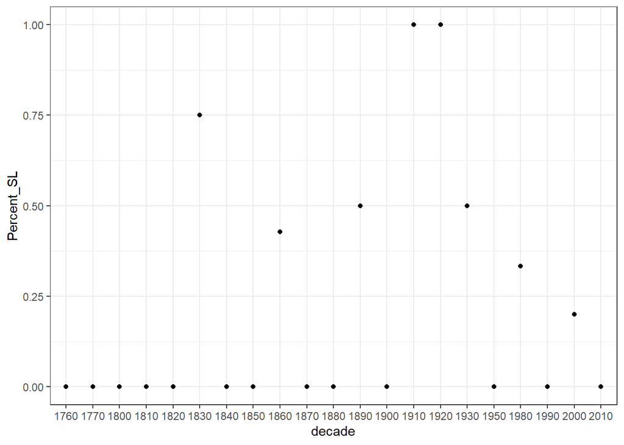

There is no trend in the percent of CSsl (diagnostic differences) through time; hypothesis not supported.

## Prevailing theories of nature and species origins - More CS in fragmented habitats in species described before Darwin?

```
##
##              1 10 100 25  5
##   1756-1859  0  4   2 22  5
##   1860-1980  1 12   2 21  9
##   1981-2020  1  2   3  3  5
```

```
##
##  Pearson's Chi-squared test
##
## data:  breaks_HKK$decade_bin and breaks_HKK$HKK
## X-squared = 15.062, df = 8, p-value = 0.05795
```

```
##                     1        10        100        25         5
## pre_Darwin 0.00000000 0.1212121 0.06060606 0.6666667 0.1515152
## pre_Kimura 0.02222222 0.2666667 0.04444444 0.4666667 0.2000000
## modern     0.07142857 0.1428571 0.21428571 0.2142857 0.3571429
```

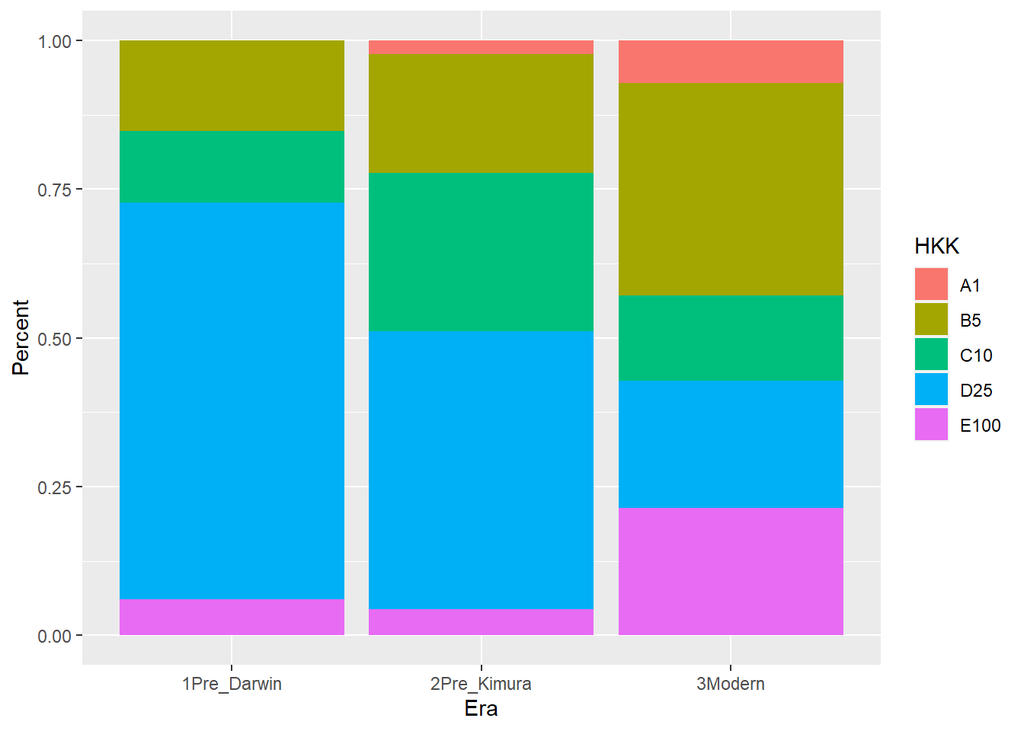

This is marginally significant. HKK=5 and 100 both trend UP, and 25 trends DOWN. A bit messy.

## Accessibility of habitat when species described - Percentage of CS in inaccessible habitats higher in earlier spp?

```
##
##        Difficult Easy Normal
##   1750         0    0      2
##   1760         0    0      3
##   1770         0    2      4
##   1800         0    1      1
##   1810         0    0      1
##   1820         0    1      1
##   1830         1    2      6
##   1840         0    0      8
##   1850         1    0      3
##   1860         0    6     13
##   1870         1    1      6
##   1880         1    0      2
##   1890         0    1      1
##   1900         0    0      4
##   1910         0    0      1
##   1920         0    1      5
##   1930         0    1      3
##   1940         0    0      1
##   1950         0    0      4
##   1960         0    0      3
##   1970         0    1      3
##   1980         2    1      2
##   1990         0    1      0
##   2000         0    4      4
##   2010         2    1      1
```

```
##
##  Pearson's Chi-squared test
##
## data:  decadeAccess$decade and decadeAccess$Access
## X-squared = 53.661, df = 48, p-value = 0.2663
```

[figure not shown]

No real trend or support..

## In sum, when we only look at species with CS (i.e. our database), the effect of taxonomic work goes away. This is interesting since that was the strongest effect in paper 1. THIS IS STILL TRUE with the annelids.

## Effect of recent divergence - dispersal

## Larval type – Planktotrophic/pelagic larvae leads to less CS/NS)?

Note1: for this I’m working with a separate surveylarv input file where I have corrected larval types to pt, lt, dd, and removed all others, including cases where there are multiple types checked. (Most of those cases are where the two CS have different larvae.) This left 59 CS with larval info.

Note2: the data fail the homoscedasticity test (Bartlett’s) so I’ve used a nonparametric Kruskal-Wallis test to see if CS/NS is different among groups.

```
##       DD       LT       PT
## 3.777778 2.571429 3.023256
```

```
##        DD        LT        PT
## 2.9907264 0.7867958 1.8320997
```

```
##
##  Kruskal-Wallis rank sum test
##
## data:  as.numeric(larv_NbCS$Nb_CS) and larv_NbCS$Larv_type
## Kruskal-Wallis chi-squared = 0.24525, df = 2, p-value = 0.8846
```

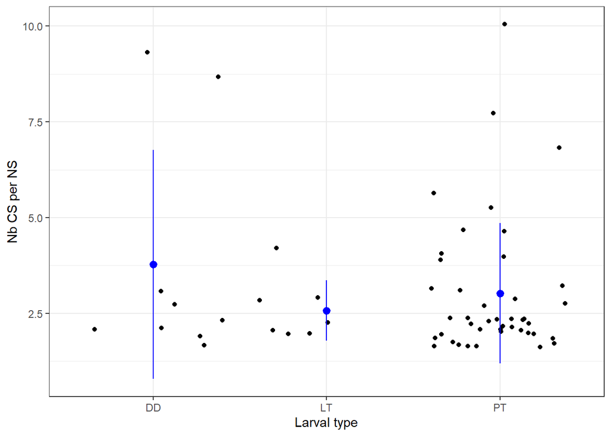

Hypothesis not supported.

##High HKK leads to more CS ss – testing this based on Nb_CS per HKK. Note: data again failed homoscedasticity, using Kruskal Wallis test

```
##        1        5       10       25      100
## 5.000000 3.454545 2.842105 2.791667 3.600000
```

```
##        1        5       10       25      100
## 3.535534 2.649839 1.740471 1.515289 1.816590
```

```
##
##  Kruskal-Wallis rank sum test
##
## data:  HKK_NbCS$Nb_CS and HKK_NbCS$HKKv3
## Kruskal-Wallis chi-squared = 6.1475, df = 4, p-value = 0.1884
```

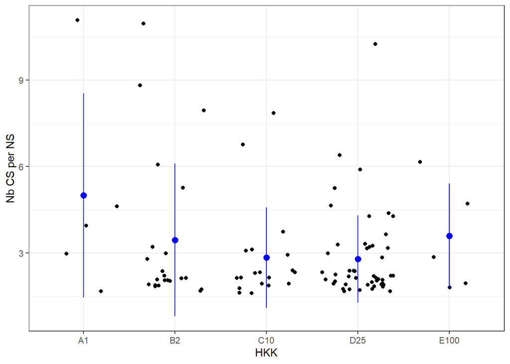

Result: Hypothesis not supported.

## In sum, NO support for the role of recent divergence as measured by a proxy of dispersal when considering only the annelids.

## More stable environments = more CSss or statistical differences

Note: stable = pelagic, deepsea, cave, coralreef; not stable = coastal, intertidal, estuarine, seagrass

```
##
##         FALSE TRUE
##   FALSE     9    5
##   TRUE     28    8
```

```
##
##  Pearson's Chi-squared test with Yates' continuity correction
##
## data:  stable_hab$CSss and stable_hab$Stable
## X-squared = 0.38136, df = 1, p-value = 0.5369
```

```
##                FALSE      TRUE
## CSss_total 0.7567568 0.6153846
## CSsl_total 0.2432432 0.3846154
```

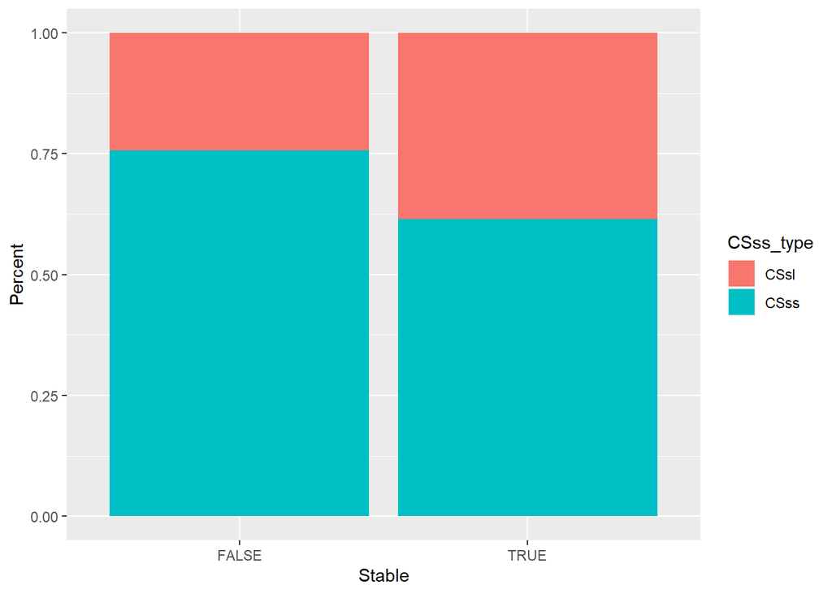

Result: Hypothesis not supported; no differences.

## Note also that stabilizing selection predicts more CSss than CSsl, which is what we find (see above).

## In sum, we generally have some support for this idea.

## High Ne (neutral hypotheses)

##Reproductive investment - Low reproductive investment leads to more statistical divergence? (Repro. investment proxy for Ne) Note1: Again this uses the surveylarv dataset with hand cleaning. Note2: Planktotrophic = LOW; Lecithotrophic, Brooding, DD = HIGH; If a spp could be both low and high, have marked it NA (is usually bc the CS have different larval types). Anything else got marked NA to be conservative. Note3: Only 29 cases are considered here, meaning that is where we have morphological data AND larval type data AND Annelid

```
##
##                      HIGH LOW
##   Diagnostic            1   9
##   No differentiation    3   7
##   Statistic             2   7
```

```
##
##  Pearson's Chi-squared test
##
## data:  surveylarv$Morpho_diff and surveylarv$Repro_invest
## X-squared = 1.2375, df = 2, p-value = 0.5386
```

Result: not significant.

## High HKK leads to more CS ss (HKK as proxy for Ne)

```
##
##                      1 5 10 25 100
##   Diagnostic         1 2  6  3   1
##   No differentiation 0 2  3  6   4
##   Statistic          0 8  6  3   0
```

```
##            1         5  10   25 100
## stat_total 0 0.6666667 0.4 0.25 0.0
## diag_total 1 0.1666667 0.4 0.25 0.2
## nod_total  0 0.1666667 0.2 0.50 0.8
```

```
##
##   1   5  10  25 100
##   1  12  15  12   5
```

```
##
##  Pearson's Chi-squared test
##
## data:  surveymorpho$Morpho_diff and surveymorpho$HKKv3
## X-squared = 15.067, df = 8, p-value = 0.05785
```

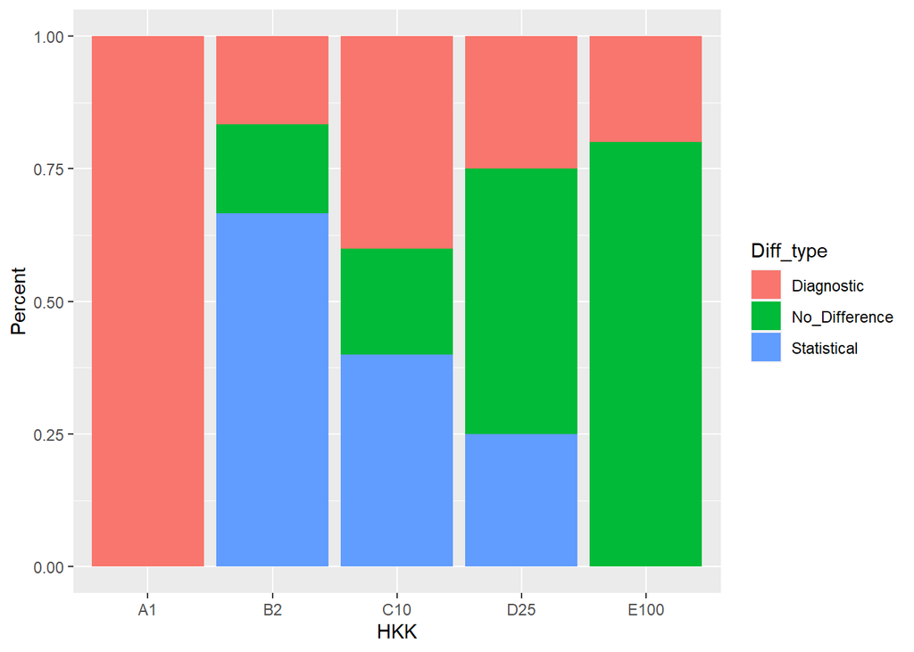

```
##
##       FALSE TRUE
##   1       1    0
##   5       2   10
##   10      6    9
##   25      3    9
##   100     1    4
```

```
##
##  Pearson's Chi-squared test
##
## data:  surveymorpho$HKKv3 and surveymorpho$CSss
## X-squared = 4.5162, df = 4, p-value = 0.3406
```

```
##            1         5  10   25 100
## CSss_total 0 0.8333333 0.6 0.75 0.8
## CSsl_total 1 0.1666667 0.4 0.25 0.2
```

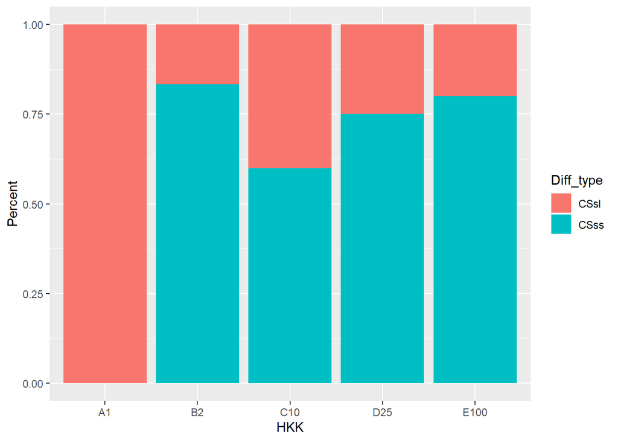

## In sum, we do not see support for the neutral hypothesis in the annelids.

## Hypothesis: effect of recent divergence – More sympatric than allopatric CS/NS for a given Nsg?

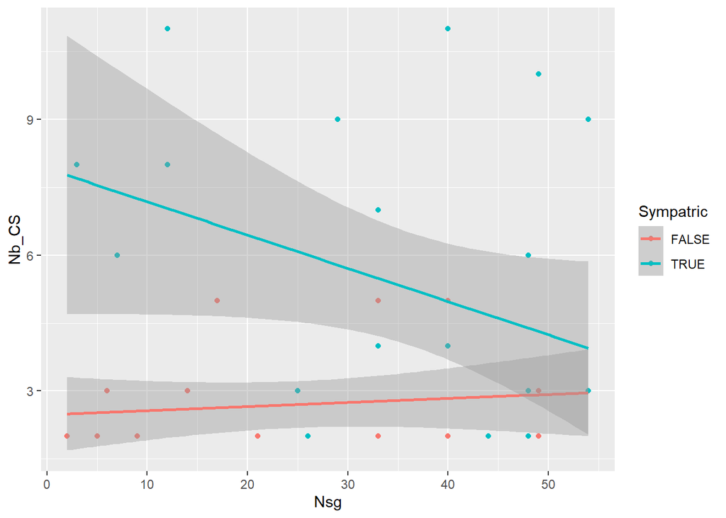

```
## ANOVA Table (type II tests)
##
##      Effect DFn DFd     F     p p<.05   ges
## 1     Nb_CS   1  41 1.661 0.205       0.039
## 2 Sympatric   1  41 6.732 0.013     * 0.141
```

## Selection against hybrids – More diagnostic differences in sympatry than allopatry?

```
##
##         FALSE TRUE
##   FALSE     3    7
##   TRUE      8    8
```

```
##
##  Pearson's Chi-squared test with Yates' continuity correction
##
## data:  surveymorpho$CSss and surveymorpho$Sympatric
## X-squared = 0.35553, df = 1, p-value = 0.551
```

```
##                FALSE      TRUE
## CSss_total 0.7272727 0.5333333
## CSsl_total 0.2727273 0.4666667
```

[figure not shown]

Result: hypothesis not supported, but v small sample sizes here.

## Importance of biological traits

# More diagnostic traits with hard skeleton?

```
##
##                       N  Y
##   Diagnostic         14  0
##   No differentiation 17  0
##   Statistic          19  0
```

```
##               N   Y
## stat_total 0.38 NaN
## diag_total 0.28 NaN
## nod_total  0.34 NaN
```

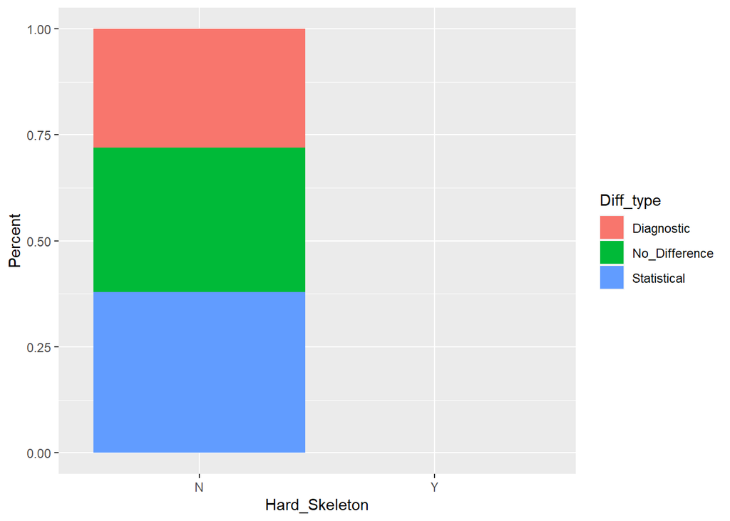

Nobody has a hard skeleton, so no test.

## More diagnostic traits with image vision?

```
##
##                       N  Y
##   Diagnostic         14  0
##   No differentiation 17  0
##   Statistic          19  0
```

```
##               N   Y
## stat_total 0.38 NaN
## diag_total 0.28 NaN
## nod_total  0.34 NaN
```

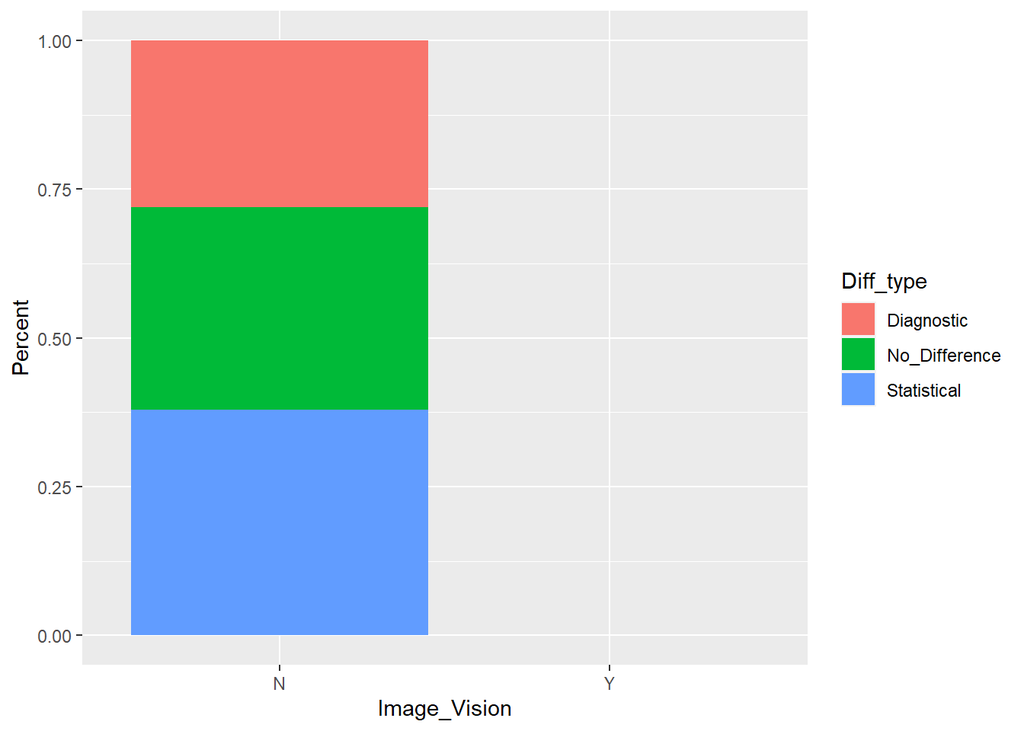

Result: No image vision, so no test.

## More diagnostic traits with internal fertilization?

```
##
##                       B  E  I
##   Diagnostic         12  2  0
##   No differentiation 16  1  0
##   Statistic          19  0  0
```

```
##
##  Pearson's Chi-squared test
##
## data:  surveymorpho$Morpho_diff and surveymorpho$ferti
## X-squared = 2.9173, df = 2, p-value = 0.2325
```

```
##                    B         E   I
## stat_total 0.4042553 0.0000000 NaN
## diag_total 0.2553191 0.6666667 NaN
## nod_total  0.3404255 0.3333333 NaN
```

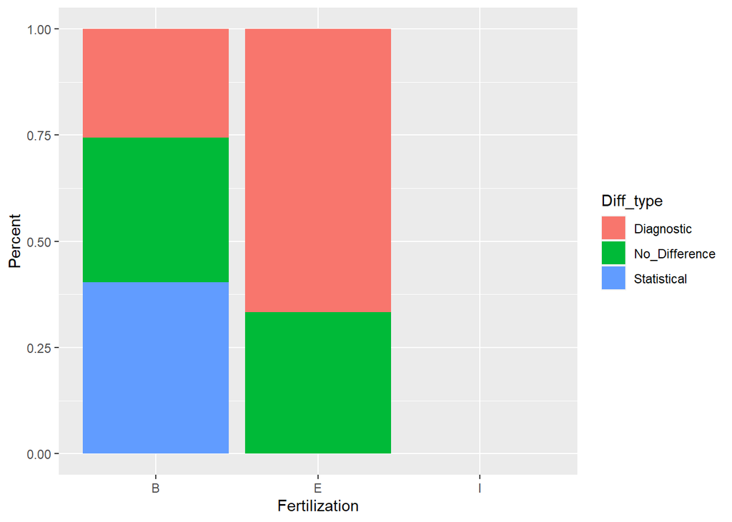

Result: hypothesis not supported. VERY small number (3) with external fertilization; most are ‘both’.

## More diagnostic traits with external genitalia?

```
##
##                       B  N  Y
##   Diagnostic          0 14  0
##   No differentiation  0 17  0
##   Statistic           0 19  0
```

```
##              B    N   Y
## stat_total NaN 0.38 NaN
## diag_total NaN 0.28 NaN
## nod_total  NaN 0.34 NaN
```

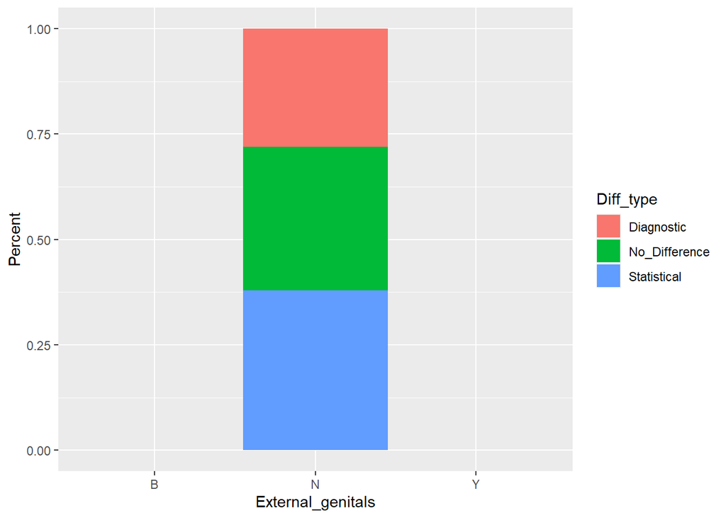

Result: No test, everyone lacks genitalia.

## In sum, biological traits don’t really have a role here - they’re mostly fixed in the phylum.

## So, overall conclusions: much like the cnidarians, there’s not support for very much here. Might be because of low sample size but might ALSO be because there’s just really high percentages of CS in this group (Cnidarians and Annelids are among the highest percentage) so we can’t pick out a signal beyond that.